# Homework 03

## Question 1: Build an `explain-to-me` skill

Create a small skill named `explain-to-me` that helps you understand a homework question.

1. Design your `SKILL.md` file so that, when you explicitly ask your agent to use the skill to read a homework question, the agent communicates with you and explains what the question is asking.
2. Keep the skill file short. It should contain a few useful rules, instructions, and a clear statement of your intent. For example, you may ask the agent to explain the goal of the question, clarify what work is required, and point you to an appropriate section of the Week 3 lectures: [Ridge Regression: Stability Through Shrinkage](https://teazrq.github.io/stat432rpy/topics/ridge-regression/ridge-regression.html) or [From a Penalized Objective to a Fitted Ridge Model](https://teazrq.github.io/stat432rpy/topics/ridge-regression/optimization-and-cross-validation.html). The skill should help you understand the question without completing the solution for you.
3. Create the skill yourself or with the help of AI. Save it as `explain-to-me/SKILL.md`. Then ask your AI agent to install the skill using its normal skill-installation method. Test it by explicitly asking the agent to use `explain-to-me` to read and explain Question 2.
4. If the skill does not work well, or if it begins to disturb your usual workflow, ask your agent to remove the installed skill. You may revise and reinstall it if you wish.
5. In all cases, append the complete contents of your developed `explain-to-me/SKILL.md` file at the end of your Homework 3 submission under the heading **`explain-to-me` skill**.

## Question 2: Ridge regression with nearly collinear predictors

Let $n=100$. Generate mutually independent standard normal random variables

$$L_i, U_{i1}, U_{i2}, X_{i3}, X_{i4},
\qquad i=1,\ldots,n,$$

and define

$$X_{i1}=L_i+0.04U_{i1},
\qquad
X_{i2}=L_i+0.04U_{i2}.$$

Center and standardize each column of $\mathbf X$ to have mean zero and average squared value one, following the [lecture’s scaling convention](https://teazrq.github.io/stat432rpy/topics/ridge-regression/ridge-regression.html#put-every-covariate-on-a-common-scale).

Continue to use $\mathbf X\in\mathbb R^{n\times p}$ for the standardized matrix and keep it fixed throughout the question, where $p=4$ is the number of predictors. The unpenalized intercept gives $p+1=5$ total fitted coefficients. Let

$$\boldsymbol\beta
=
(1.5,1.5,1,0)^{\mathsf T},
\qquad
\boldsymbol\mu
=
\mathbf X\boldsymbol\beta.$$

Generate a training response and an independent test response at the same predictor values:

$$\begin{aligned}
\mathbf y
&=
\boldsymbol\mu+\boldsymbol\epsilon,\\
\mathbf y^*
&=
\boldsymbol\mu+\boldsymbol\epsilon^*,
\end{aligned}$$

where

$$\boldsymbol\epsilon,
\boldsymbol\epsilon^*
\overset{\mathrm{ind}}{\sim}
\mathcal N_n(\mathbf0,\mathbf I_n).$$

Center the training response as $\widetilde{\mathbf y}=\mathbf y-\bar y\mathbf1_n$. For each $\lambda\in\{0,0.02,0.2\}$, fit the slopes using the lecture’s ridge formula:

$$\widehat{\boldsymbol\beta}_\lambda
=
\left(\mathbf X^{\mathsf T}\mathbf X+n\lambda\mathbf I_p\right)^{-1}
\mathbf X^{\mathsf T}\widetilde{\mathbf y}.$$

The unpenalized intercept is $\widehat\beta_0=\bar y$; add this training mean back when predicting either response. The case $\lambda=0$ is ordinary least squares. Use seed `43231` before generating the design and responses. R and Python use different random-number generators, so their exact numerical results need not agree.

1. Generate $\mathbf X$ once. Report the correlation between its first two columns and its largest and smallest singular values. Use these quantities to explain why the estimator contrast $\widehat\beta_1-\widehat\beta_2$ should be much more variable than $\widehat\beta_1+\widehat\beta_2$.

   **Show the workflow**

   ```r
   # Adapated from https://teazrq.github.io/stat432rpy/topics/ridge-regression/ridge-regression.html
   set.seed(43231)
   n <- 100
   p <- 4

   # Make the first two raw covariates nearly redundant
   L <- rnorm(n)
   U1 <- rnorm(n)
   U2 <- rnorm(n)
   X_raw <- cbind(
     x1 = L + 0.04 * U1,
     x2 = L + 0.04 * U2,
     x3 = rnorm(n),
     x4 = rnorm(n)
   )

   feature_names <- colnames(X_raw)

   # Center each covariate so its average squared value is one
   x_bar <- colMeans(X_raw)

   # Subtract the mean of each column from X_raw
   X <- sweep(x = X_raw, MARGIN = 2, STATS = x_bar, FUN = "-")

   # colMeans(X^2) = (X_raw - x_bar)^2
   s <- sqrt(colMeans(X^2))

   # Divide X by s
   X <- sweep(X, MARGIN = 2, STATS = s, FUN = "/")

   beta <- c(1.5, 1.5, 1, 0)
   mu <- drop(X %*% beta)

   # Save the genuine raw covarites. Each language then performs the stated
   # centering and standardization before fitting.
   ridge_data <- data.frame(row_id = seq_len(n),
                            X_raw, mu = mu,
                            check.names = FALSE
                            )

   dir.create("data/week-03", recursive = TRUE, showWarnings = FALSE)
   write.csv(ridge_data, "data/week-03/fixed-x.csv", row.names = FALSE)

   # svd() breaks down any matrix into three simpler matrices
   singular_values <- svd(X, nu = 0, nv = 0)$d
   round(c(
     "Cor(x1, x2)" = cor(X[, 1], X[, 2]),
     "Largest singular value" = max(singular_values),
     "Smallest singular value"  = min(singular_values),
     "Condition number" = (max(singular_values) / min(singular_values))^2
   ), 3)
   ```

   ```
               Cor(x1, x2)  Largest singular value Smallest singular value
                     0.998                  14.141                   0.475
          Condition number
                   885.012
   ```

   $X_1$ and $X_2$ are highly correlated, which makes them nearly collinear. Since these two predictors are nearly identical, small changes in the data (due to variability) do not affect the coefficients in the model with $\widehat\beta_1+\widehat\beta_2$ as much. If $\widehat\beta_1$ decreases, then $\widehat\beta_2$ increases and vice versa, but their sum ($\widehat\beta_1+\widehat\beta_2$) remains the same. The estimator contrast $\widehat\beta_1-\widehat\beta_2$ should be much more variable than $\widehat\beta_1+\widehat\beta_2$ because changes in the coefficients (due to random noise or variability) would result in variable differences.
2. Independently repeat the generation of $\mathbf y$ and $\mathbf y^*$, followed by all three fits, 200 times while keeping $\mathbf X$ fixed. Draw the training and test noise inside each repetition, then reuse that realized pair for all three values of $\lambda$. For each value of $\lambda$, report the empirical mean and standard deviation of

$$\widehat\beta_1,
\quad
\widehat\beta_2,
\quad
\widehat\beta_1+\widehat\beta_2,
\quad
\widehat\beta_1-\widehat\beta_2.$$
Also report the average training MSE and the average test MSE calculated from the independent test response, where

$$\operatorname{MSE}_{\mathrm{test}}
=
\frac{1}{n}
\left\lVert
\mathbf y^*
-
\widehat\beta_0\mathbf1_n
-
\mathbf X\widehat{\boldsymbol\beta}
\right\rVert_2^2.$$

**Show the workflow**

```r
lambda_grid <- c(0, 0.02, 0.2)
repetitions <- 200

# Repeat the experiment. New noise is drawn only when a run begins.
train_mse_draws <- matrix(NA_real_,
                          nrow = repetitions,
                          ncol = length(lambda_grid))
test_mse_draws <- matrix(NA_real_,
                          nrow = repetitions,
                          ncol = length(lambda_grid))

# Axes index repetitions, coefficients, and penalities.
# beta_hat[simulation run, coefficients 1-4, which lambda]
beta_hat <- array(NA_real_, dim = c(repetitions, p, length(lambda_grid)))

# Keep X fixed by not using X inside the loop
sigma <- 1
for (k in seq_len(repetitions)) {
  train_error <- rnorm(n, sd = sigma)
  test_error <- rnorm(n, sd = sigma)

  # Generating a training and test response at the same predictor values
  y_train <- mu + train_error
  y_test <- mu + test_error
  y_bar <- mean(y_train)
  y_centered <- y_train - y_bar

  # Reuse this run's realized training/test pair across all penalties.
  for (l in seq_along(lambda_grid)) {
    lambda <- lambda_grid[l]

    # Solve for beta_hat at each lambda value
    beta_hat[k, , l] <- solve(
      t(X) %*% X + n * lambda * diag(p), t(X) %*% y_centered
      )

    # Add training mean back when predicting
    y_hat <- y_bar + drop(X %*% beta_hat[k, , l])

    # Store train and test mse inside matrices
    train_mse_draws[k, l] <- mean((y_train - y_hat)^2)
    test_mse_draws[k, l] <- mean((y_test - y_hat)^2)
  }

}

# Report empirical mean and sd of beta_hats
beta1_hat_L1m <- mean(beta_hat[, 1, 1])
beta2_hat_L1m <- mean(beta_hat[, 2, 1])

beta1_hat_L2m <- mean(beta_hat[, 1, 2])
beta2_hat_L2m <- mean(beta_hat[, 2, 2])

beta1_hat_L3m <- mean(beta_hat[, 1, 3])
beta2_hat_L3m <- mean(beta_hat[, 2, 3])

beta1_hat_L1s <- sd(beta_hat[, 1, 1])
beta2_hat_L1s <- sd(beta_hat[, 2, 1])

beta1_hat_L2s <- sd(beta_hat[, 1, 2])
beta2_hat_L2s <- sd(beta_hat[, 2, 2])

beta1_hat_L3s <- sd(beta_hat[, 1, 3])
beta2_hat_L3s <- sd(beta_hat[, 2, 3])

sum_beta1_beta2_L1m <- beta1_hat_L1m + beta2_hat_L1m
sum_beta1_beta2_L2m <- beta1_hat_L2m + beta2_hat_L2m
sum_beta1_beta2_L3m <- beta1_hat_L3m + beta2_hat_L3m

sum_beta1_beta2_L1s <- sd(beta_hat[, 1, 1] + beta_hat[, 2, 1])
sum_beta1_beta2_L2s <- sd(beta_hat[, 1, 2] + beta_hat[, 2, 2])
sum_beta1_beta2_L3s <- sd(beta_hat[, 1, 3] + beta_hat[, 2, 3])

diff_beta1_beta2_L1m <- beta1_hat_L1m - beta2_hat_L1m
diff_beta1_beta2_L2m <- beta1_hat_L2m - beta2_hat_L2m
diff_beta1_beta2_L3m <- beta1_hat_L3m - beta2_hat_L3m

diff_beta1_beta2_L1s <- sd(beta_hat[, 1, 1] - beta_hat[, 2, 1])
diff_beta1_beta2_L2s <- sd(beta_hat[, 1, 2] - beta_hat[, 2, 2])
diff_beta1_beta2_L3s <- sd(beta_hat[, 1, 3] - beta_hat[, 2, 3])

data.frame(
  lambda = lambda_grid,

  # beta1_hat
  mean_beta1_hat = c(beta1_hat_L1m, beta1_hat_L2m, beta1_hat_L3m),
  sd_beta1_hat = c(beta1_hat_L1s, beta1_hat_L2s, beta1_hat_L3s),

  # beta2_hat
  mean_beta2_hat = c(beta2_hat_L1m, beta2_hat_L2m, beta2_hat_L3m),
  sd_beta2_hat = c(beta2_hat_L1s, beta2_hat_L2s, beta2_hat_L3s),

  # beta1_hat + beta2_hat
  mean_sum_beta1_beta2 =
    c(sum_beta1_beta2_L1m, sum_beta1_beta2_L2m, sum_beta1_beta2_L3m),
  sd_sum_beta1_beta2 =
    c(sum_beta1_beta2_L1s, sum_beta1_beta2_L2s, sum_beta1_beta2_L3s),

  # beta1_hat - beta2_hat
  mean_diff_beta1_beta2 =
    c(diff_beta1_beta2_L1m, diff_beta1_beta2_L2m, diff_beta1_beta2_L3m),
  sd_diff_beta1_beta2 =
    c(diff_beta1_beta2_L1s, diff_beta1_beta2_L2s, diff_beta1_beta2_L3s),

  # average training and test mses
  train_mse = colMeans(train_mse_draws),
  test_mse = colMeans(test_mse_draws)
)
```

```
  lambda mean_beta1_hat sd_beta1_hat mean_beta2_hat sd_beta2_hat
1   0.00       1.495589   1.54394848       1.509765   1.54858847
2   0.02       1.486994   0.16151331       1.489176   0.16591120
3   0.20       1.367908   0.04570277       1.368693   0.04733702
  mean_sum_beta1_beta2 sd_sum_beta1_beta2 mean_diff_beta1_beta2
1             3.005354         0.09510778          -0.014175478
2             2.976171         0.09416526          -0.002181997
3             2.736601         0.08646679          -0.000785071
  sd_diff_beta1_beta2 train_mse test_mse
1          3.09107762 0.9647563 1.062452
2          0.31362247 0.9746809 1.049262
3          0.03438848 1.0767603 1.133484
```

3. Interpret the coefficient estimates and test MSE using bias and variance. Explain why ridge can substantially stabilize the individual coefficients without producing an equally large change in the fitted values.

   The larger the penalty (as $\lambda$ increases), $\hat{\beta_1}$ and $\hat{\beta_2}$ deviate from 1.5, which is the true mean coefficient parameter for the first two predictors. In addition, the ridge pulls the coefficients towards zero as $\lambda$ increases, so their standard deviations decrease (less variance). However, the estimated coefficients may become more biased because they are no longer centered close to their true value of 1.5. Ridge can substantially stabilize the individual coefficients without producing an equally large change in the fitted values because $X_1$ and $X_2$ are nearly identical. $\hat{\beta_1} + \hat{\beta_2}$ is around 3 for all cases of $\lambda$, which means that if one coefficient decreases while the other increases, their effects on the fitted values cancel out. The test MSE fluctuates as $\lambda$ increases because each repetition uses a new, randomly generated test response. There is a bias-variance trade off when penalty increases; a lower penalty correlates to a lower bias but higher variance whereas a higher penalty correlates to a higher bias but lower variance (since the coefficients are pulled towards zero).

## Question 3: What does ridge regression shrink?

Let $\mathbf X\in\mathbb R^{n\times p}$ be a centered predictor matrix, and let $\widetilde{\mathbf y}\in\mathbb R^n$ be the centered response. Use the supplied predictor scales for this algebraic question; the columns need not have unit variance. Here $p$ counts predictors, $\boldsymbol\beta\in\mathbb R^p$ contains their slopes, and $p+1$ counts all fitted coefficients, including the separately fitted, unpenalized intercept. Ridge regression minimizes

$$L_\lambda(\boldsymbol\beta)
=
\frac{1}{2n}
\left\lVert
\widetilde{\mathbf y}-\mathbf X\boldsymbol\beta
\right\rVert_2^2
+
\frac{\lambda}{2}
\lVert\boldsymbol\beta\rVert_2^2.$$

1. Derive the ridge normal equation

$$\left(
\mathbf X^{\mathsf T}\mathbf X
+n\lambda\mathbf I_p
\right)
\widehat{\boldsymbol\beta}_\lambda
=
\mathbf X^{\mathsf T}\widetilde{\mathbf y}.$$

Explain why it has a unique solution whenever $\lambda>0$, even if $\mathbf X$ is rank deficient or $p>n$.

Adapted from Lecture 3 Notes: Understand ridge shrinkage mathematically, differentiate $L_{\lambda}(\beta)$ with respect to $\beta$ and set the gradient to zero

$$-\frac{1}{n}X^T (\widetilde{y} - X\widehat{\beta_{\lambda}}) + \lambda\widehat{\beta_{\lambda}} = 0$$

Distribute $-\frac{1}{n} X^T$, multiply by $n$, and factor out $\widehat{\beta_{\lambda}}$ results in

$$(X^TX + n\lambda I_p)\widehat{\beta_{\lambda}} = X^T\widetilde{y}$$

Solve for $\widehat{\beta_{\lambda}}$

$$\widehat{\beta_{\lambda}} =(X^TX + n\lambda I_p)^{-1} X^T\widetilde{y}$$

The ridge normal equation has a unique solution whenever $\lambda > 0$, even if $X$ is rank deficient or $p > n$ because the added diagonal term makes the matrix invertible. Adding $n\lambda I_p$ puts a positive value on every diagonal direction.

2. Let

$$\mathbf X
=
\mathbf U_r\mathbf D_r\mathbf V_r^{\mathsf T}$$

be a compact singular value decomposition, where $r=\operatorname{rank}(\mathbf X)$, $\mathbf U_r\in\mathbb R^{n\times r}$, $\mathbf D_r\in\mathbb R^{r\times r}$, and $\mathbf V_r\in\mathbb R^{p\times r}$. Show that ridge multiplies the fitted response component in the $j$th left singular-vector direction, for $j=1,\ldots,r$, by

$$\rho_j(\lambda)
=
\frac{d_j^2}{d_j^2+n\lambda}.$$

Using the definition of $X$, we know that

$$X^T X = (V_r D_r U_r^T)(U_r D_r V_r^T) = V_r D_r^2 V_r^T$$

Pluging $X$ into $\widehat{\beta_{\lambda}}$ results in

$$\widehat{\beta_{\lambda}} = (V_r D_r^2 V_r^T + n\lambda I_p)^{-1} (V_r D_r U_r^T)\widetilde{y} = V_r (D_r^2 + n\lambda I_r)^{-1} D_r U_r^T \widetilde{y}$$

Multiply $X$ and $\widehat{\beta_{\lambda}}$

$$X \widehat{\beta_{\lambda}} = (U_r D_r V_r^T)[V_r (D_r^2 + n\lambda I_r)^{-1} D_r U_r^T \widetilde{y}] = \sum_{j = 1}^{r} \frac{d_j^2}{d_j^2 + n \lambda} u_j u_j^T \widetilde{y}$$

Suppose $n=100$, $\lambda=0.01$, and the nonzero singular values are

$$d_1=10,
\qquad
d_2=2,
\qquad
d_3=0.2.$$

Calculate the three shrinkage factors and the total effective degrees of freedom, including the unpenalized intercept:

$$\operatorname{df}_{\mathrm{eff}}(\lambda)
=
1+\sum_{j=1}^3\rho_j(\lambda).$$

**Show the workflow**

```r
n_shrink <- 100
lambda_shrink <- 0.01
d <- c(10, 2, 0.2)

# Calculate shrinkage factors
rho_1 <- d[1]^2 / (d[1]^2 + n_shrink * lambda_shrink)
rho_2 <- d[2]^2 / (d[2]^2 + n_shrink * lambda_shrink)
rho_3 <- d[3]^2 / (d[3]^2 + n_shrink * lambda_shrink)

data.frame(
  rho = c("rho_1", "rho_2", "rho_3"),
  rho_calc = c(rho_1, rho_2, rho_3)
)
```

```
    rho   rho_calc
1 rho_1 0.99009901
2 rho_2 0.80000000
3 rho_3 0.03846154
```

**Show the workflow**

```r
# Calculate total effective degrees of freedom with the unpenalized intercept
df_eff <- 1 + sum(c(rho_1, rho_2, rho_3))
```

The total effective degrees of freedom, including the unpenalized intercept, is 2.829.

3. Which direction receives the strongest shrinkage? Explain why shrinking this direction can reduce prediction variance. Under what circumstance could the same shrinkage produce substantial prediction bias?

   The third direction, $d_3 = 0.2$, receives the strongest shrinkage because its shrinkage factor is the smallest at 0.038. Shrinking this direction can reduce prediction variance because the data provides little information in that direction, which means that the direction has little influence on the model’s prediction (i.e., shrinking reduces sensitivity to random noise). The same shrinkage could produce substantial prediction bias when the weak direction contains real, important information about the response.

## Question 4: Ridge regression and optimization

Let $\mathbf X\in\mathbb R^{n\times p}$ be a centered predictor matrix with $p=2$. Its columns need not have unit variance in this question. The intercept is fitted separately and is not penalized. Suppose the two eigenvalues of

$$\mathbf A_0
=
\frac{1}{n}\mathbf X^{\mathsf T}\mathbf X$$

are $9$ and $0.01$. Ridge regression with $\lambda=0.09$ has curvature matrix

$$\mathbf A_\lambda
=
\frac{1}{n}\mathbf X^{\mathsf T}\mathbf X
+
\lambda\mathbf I_p.$$

1. Calculate the condition numbers of $\mathbf A_0$ and $\mathbf A_\lambda$. Explain what the change says about the geometry of the ridge objective.

   The condition number is the ratio of the largest eigenvalue and the smallest eigenvalue.

   **Show the workflow**

   ```r
   # k(A) = largest eigenvalue / smallest eigvenvalue
   k_A0 <- 9 / 0.01

   k_lambda <- 0.09
   k_Alambda <- (9 + k_lambda) / (0.01 + k_lambda)

   data.frame(
     A = c("A0", "A_lambda"),
     Condition_Number = c(k_A0, k_Alambda)
   )
   ```

   ```
            A Condition_Number
   1       A0            900.0
   2 A_lambda             90.9
   ```

   The condition number decreased from 900 to 90.9. This means that the ridge makes the objective less curved and less elongated.
2. Gradient descent uses

$$\boldsymbol\beta^{(k+1)}
=
\boldsymbol\beta^{(k)}
-
\eta\nabla L_\lambda\!\left(\boldsymbol\beta^{(k)}\right).$$

Let $\widehat{\boldsymbol\beta}_\lambda$ be the ridge minimizer and define the optimization error

$$\mathbf e^{(k)}
=
\boldsymbol\beta^{(k)}
-
\widehat{\boldsymbol\beta}_\lambda.$$

Show that the component of $\mathbf e^{(k)}$ in an eigendirection with unpenalized eigenvalue $a$ is multiplied at each step by

$$1-\eta(a+\lambda).$$

Since the ridge objective is quadratic, the gradient descent can be written as

$$\nabla L_{\lambda}(\beta) = A_{\lambda} e^{(k)}$$

By subtracting $\widehat{\beta_{\lambda}}$ on both sides of the gradient descent, we get

$$\beta^{(k+1)} - \widehat{\beta_{\lambda}} = \beta^{(k)} - \widehat{\beta_{\lambda}} - \eta \nabla L_{\lambda}(\beta)$$

Substitute in the optimization error to get

$$e^{(k+1)} = e^{(k)} - \eta A_{\lambda} e^{(k)} = (I_p - \eta A_{\lambda}) e^{(k)}$$

In an eigendirection whose unpenalized eigenvalue is $a$, $\mathbf A_\lambda$ has eigenvalue $a+\lambda$. The corresponding error component is therefore multiplied by $1-\eta(a+\lambda)$.

Let $M=9.09$, the largest eigenvalue of $\mathbf A_\lambda$. Find the interval of step sizes that contracts every eigendirection. Then compare these two choices:

- For $\eta=1/M$, calculate the two contraction factors and explain which direction converges faster.

**Show the workflow**

```r
M <- 9.09
eta_1 <- 1 / M

c_large_1 <- 1 - eta_1 * (9 + k_lambda)
c_small_1 <- 1 - eta_1 * (0.01 + k_lambda)
```

For eigenvalues of 9 (strong direction) and 0.01 (weak direction), the contraction factors are 0 and 0.989 respectively. The strong direction converges faster because the error disappears in one step whereas the weak direction error decreases slowly.

- For $\eta=2.1/M$, determine whether the method converges. Assume the initial error has a nonzero component in the eigendirection corresponding to $M$.

**Show the workflow**

```r
eta_2.1 <- 2.1 / M

c_large_2.1 <- 1 - eta_2.1 * (9 + k_lambda)
c_small_2.1 <- 1 - eta_2.1 * (0.01 + k_lambda)
```

The method does not converge if the absolute value of the contraction factor is greater than 1. In this example, the strong direction has a contraction factor of -1.1. Its magnitude is greater than 1, so the method does NOT converge.

3. Increasing $\lambda$ generally improves the condition number. Explain why choosing $\lambda$ to make gradient descent converge as quickly as possible is not a valid statistical tuning rule.

   Increasing $\lambda$ generally improves the condition number (makes the optimization more balanced), but it also increases the ridge penalty. This means choosing a greater $\lambda$ shrinks the coefficients towards zero (reduces variance but increases bias). A large penalty makes the optimization run faster, but it may shrink the coefficients too much. The model may make biased predictions.

## Question 5: Selecting the ridge penalty for real-estate prediction

The supplied `data/realestate.csv` contains 414 real-estate transactions from Sindian District, New Taipei City, Taiwan. The quantitative response `price` is the unit house price. The six predictors are the transaction date, house age, distance to the nearest mass rapid transit station, number of nearby convenience stores, latitude, and longitude. Treat all six predictors as quantitative in this question. The column `row_id` identifies an observation and must not be used as a predictor.

The file `data/realestate-split-folds.csv` assigns 332 observations to the training set and 82 observations to the final test set. It also gives ten fold labels for the training observations. Match the two files using `row_id` and do not use the test responses while selecting a model.

Use the penalty grid

$$\Lambda
=
\{0\}
\mathbin{\cup}
\left\{
10^{-4+0.05l}:l=0,\ldots,120
\right\}.$$

For every fit, center and standardize each predictor using only the observations available to that fit, with the variance divided by the number of fitting observations. Center the response and leave the intercept unpenalized.

1. Perform ten-fold cross-validation over $\Lambda$ using the supplied training folds. Estimate the predictor means and scales separately within each set of nine training folds. For each $\lambda$, calculate the mean validation MSE and $\operatorname{SE}(\lambda)$, the sample standard deviation of the ten fold errors divided by $\sqrt{10}$. Use this SE for the conventional one-standard-error heuristic. Plot the mean validation MSE and identify $\lambda_{\min}$. Choose $\lambda_{\mathrm{1se}}$ as the largest candidate in $\Lambda$, including OLS, satisfying

$$\overline{\operatorname{MSE}}(\lambda)
\leq
\overline{\operatorname{MSE}}(\lambda_{\min})
+
\operatorname{SE}(\lambda_{\min}).$$

**Show the workflow**

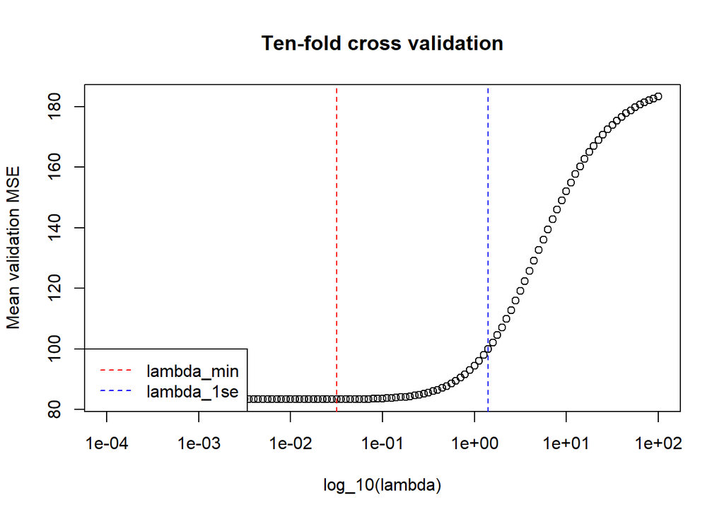

```r
# Read the .csv files
df_realestate <- read.csv("data/realestate.csv")
df_split <- read.csv("data/realestate-split-folds.csv")

n_total <- nrow(df_realestate)
n_test <- sum(df_split$split == "test")

# Match row_id to training or testing data
train_index <- df_split$row_id[df_split$split == "train"]
test_index <- df_split$row_id[df_split$split == "test"]

split_shared <- rep("train", n_total)
split_shared[test_index] <- "test"

# Give the training observations approximately equal fold sizes
fold_shared <- rep(NA_integer_, n_total)
fold_shared[train_index] <- sample(
  rep(seq_len(10), length.out = length(train_index))
  )

split_folds_shared <- data.frame(
  row_id = seq_len(n_total),
  split = split_shared,

  # Only for training observations
  # Use for 10-fold cross validation but not for test observations during model selection
  cv_fold = fold_shared
)

# Set up penalty grid
lambda_grid_shared <- c(0, 10^(-4 + 0.05 * (0:120)))

# Use the data, split, folds, and penalty grid generated above
df_realestate_r <- df_realestate
split_folds_r <- split_folds_shared
df_realestate_r$row_id <- seq_len(nrow(df_realestate_r))
df_realestate_r <- merge(
  df_realestate_r, split_folds_r, by = "row_id", all.x = TRUE, sort = FALSE
)
df_realestate_r <- df_realestate_r[order(df_realestate_r$row_id), ]

feature_names_r <- setdiff(
  names(df_realestate_r),
  c("row_id", "price", "split", "cv_fold")
)
lambda_grid_r <- lambda_grid_shared

train_rows_r <- df_realestate_r$split == "train"
test_rows_r <- df_realestate_r$split == "test"

X_train_raw_r <- as.matrix(df_realestate_r[train_rows_r, feature_names_r])
y_train_raw_r <- df_realestate_r$price[train_rows_r]

X_test_raw_r <- as.matrix(df_realestate_r[test_rows_r, feature_names_r])
y_test_raw_r <- df_realestate_r$price[test_rows_r]

fold_id_r <- df_realestate_r$cv_fold[train_rows_r]

# Fit ridge on one training sample and return coefficients on original scale
fit_ridge_model <- function(X_raw, y, lambda){
  n <- nrow(X_raw)
  p <- ncol(X_raw)

  # Standardize predictors
  x_bar <- colMeans(X_raw)
  X_centered <- sweep(X_raw, 2, x_bar, "-")
  s <- sqrt(colMeans(X_centered^2))
  X <- sweep(X_centered, 2, s, "/")

  # Center response
  # Intercept is not penalized
  y_bar <- mean(y)
  y_centered <- y - y_bar

  ridge_matrix <- crossprod(X) + n * lambda * diag(p)

  # Solve for beta_hat
  # crossprod(X) = t(X) %*% X
  beta_hat <- solve(
    crossprod(X) + n * lambda * diag(p), crossprod(X, y_centered)
  )

  beta_hat_raw <- drop(beta_hat) / s
  raw_intercept <- y_bar - sum(x_bar * beta_hat_raw)
  y_hat <- raw_intercept + drop(X_raw %*% beta_hat_raw)

  df_eff <- 1 + sum(diag(X %*% solve(ridge_matrix, t(X))))

  list(
    lambda = lambda,
    beta_hat = drop(beta_hat),
    intercept = y_bar,
    beta_hat_raw = beta_hat_raw,
    intercept_raw = raw_intercept,
    x_bar = x_bar,
    s = s,
    fitted = y_hat,
    train_mse = mean((y - y_hat)^2),
    df_eff = df_eff
  )
}

predict_ridge <- function(fit, X_new_raw){
  drop(fit$intercept_raw + X_new_raw %*% fit$beta_hat_raw)
}

# Refit preprocessing and ridge inside each cross-validation training sample
fold_levels <- sort(unique(fold_id_r))
fold_mse <- matrix(NA_real_,
                   nrow = length(fold_levels),
                   ncol = length(lambda_grid_shared)
                   )
validation_n <- integer(length(fold_levels))

for (k in seq_along(fold_levels)){
  fold <- fold_levels[k]
  validation <- fold_id_r == fold
  validation_n[k] <- sum(validation)

  X_fold_train_raw <- X_train_raw_r[!validation, , drop = FALSE]
  X_fold_validation_raw <- X_train_raw_r[validation, , drop = FALSE]

  y_fold_train <- y_train_raw_r[!validation]
  y_fold_validation <- y_train_raw_r[validation]

  for (l in seq_along(lambda_grid_r)){
    lambda <- lambda_grid_r[l]

    fit <- fit_ridge_model(
      X_raw = X_fold_train_raw,
      y = y_fold_train,
      lambda = lambda
    )

    y_validation_hat <- predict_ridge(fit, X_fold_validation_raw)

    fold_mse[k, l] <- mean((y_fold_validation - y_validation_hat)^2)
  }
}

# Apply minimum error and one standard error rules to fold errors
mean_cv_mse <- colMeans(fold_mse)
se_cv_mse <- apply(fold_mse, 2, sd) / sqrt(10)
minimum_index <- which.min(mean_cv_mse)
one_se_threshold <- mean_cv_mse[minimum_index] + se_cv_mse[minimum_index]
eligible <- which(mean_cv_mse <= one_se_threshold + 1e-12)
one_se_index <- eligible[which.max(lambda_grid_r[eligible])]
lambda_min <- lambda_grid_r[minimum_index]
lambda_1se <- lambda_grid_r[one_se_index]

cv_summary <- data.frame(
  lambda = lambda_grid_r,
  mean_validation_mse = mean_cv_mse,
  se_lambda = se_cv_mse
)

# Plot mean validation MSE
plot(cv_summary$lambda, cv_summary$mean_validation_mse,
     type = "b",
     log = "x",
     xlab = "log_10(lambda)",
     ylab = "Mean validation MSE",
     main = "Ten-fold cross validation")

abline(
  v = lambda_min,
  col = "red",
  lty = 2
)

abline(
  v = lambda_1se,
  col = "blue",
  lty = 2
)

legend(
  "bottomleft",
  legend = c("lambda_min", "lambda_1se"),
  col = c("red", "blue"),
  lty = 2
)
```

$\lambda_{min}$ is 0.0316228 (minimum CV error penalty). $\lambda_{1se}$ is 1.413 (one standard error penalty).

2. Use all $n=332$ training observations to calculate the [lecture’s GCV criterion](https://teazrq.github.io/stat432rpy/topics/ridge-regression/optimization-and-cross-validation.html#loocv-and-gcv) for each $\lambda\in\Lambda$:

$$\operatorname{GCV}(\lambda)
=
\frac{
\operatorname{MSE}_{\mathrm{train}}(\lambda)
}{
\left\{
1-\operatorname{df}_{\mathrm{eff}}(\lambda)/n
\right\}^2
}.$$

Here $\operatorname{MSE}_{\mathrm{train}}$ is the training MSE, and $\operatorname{df}_{\mathrm{eff}}$ includes the unpenalized intercept, as in Question 3. Estimate means and scales once from all training observations and keep them fixed for this calculation. Plot the GCV curve and identify $\lambda_{\mathrm{GCV}}$.

**Show the workflow**

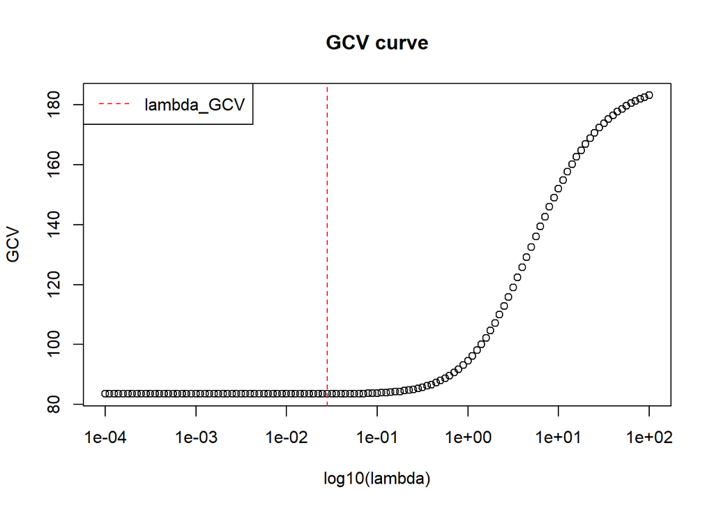

```r
gcv_results <- data.frame(
  lambda = lambda_grid_r,
  train_mse = NA_real_,
  df_eff = NA_real_,
  gcv = NA_real_
)

n_train <- nrow(X_train_raw_r)

for (l in seq_along(lambda_grid_r)){
  fit <- fit_ridge_model(
    X_raw = X_train_raw_r,
    y = y_train_raw_r,
    lambda = lambda_grid_r[l]
  )

  gcv_results$train_mse[l] <- fit$train_mse
  gcv_results$df_eff[l] <- fit$df_eff

  # Calcualte GCV(lambda)
  gcv_results$gcv[l] <- fit$train_mse / (1 - fit$df_eff / n_train)^2
}

gcv_min_index <- which.min(gcv_results$gcv)
lambda_gcv <- gcv_results$lambda[gcv_min_index]

# Plot GCV curve
plot(gcv_results$lambda, gcv_results$gcv,
     type = "b",
     log = "x",
     xlab = "log10(lambda)",
     ylab = "GCV",
     main = "GCV curve"
)

abline(
  v = max(lambda_gcv, 1e-5),
  col = "red",
  lty = 2
)

legend(
  "topleft",
  legend = "lambda_GCV",
  col = "red",
  lty = 2
)
```

$\lambda_{GCV}$ is 0.028.

3. Fix all three choices before examining the test responses. Refit OLS and ridge at $\lambda_{\min}$, $\lambda_{\mathrm{1se}}$, and $\lambda_{\mathrm{GCV}}$ using all training observations. Report each model’s training MSE, test MSE, and effective degrees of freedom. Interpret the differences and explain why the model with the smallest observed test MSE must not be selected after viewing this table.

**Show the workflow**

```r
selected_lambdas <- c(
  OLS = 0,
  lambda_min = lambda_min,
  lambda_1se = lambda_1se,
  lambda_GCV = lambda_gcv
)

# Fit all three choices using all training observations
final_fit <- lapply(
  selected_lambdas,
  function(lambda){
    fit_ridge_model(
      X_raw = X_train_raw_r,
      y = y_train_raw_r,
      lambda = lambda
    )
  }
)

# Predict the final test set
final_results <- data.frame(
  model = names(selected_lambdas),
  lambda = as.numeric(selected_lambdas),
  train_mse = vapply(
    final_fit,
    function(fit) fit$train_mse,
    numeric(1)
  ),
  test_mse = vapply(
    final_fit,
    function(fit){
      y_test_hat <- predict_ridge(fit, X_test_raw_r)
      mean((y_test_raw_r - y_test_hat)^2)
    },
    numeric(1)
  ),
  df_eff = vapply(
    final_fit,
    function(fit) fit$df_eff,
    numeric(1)
  )
)

final_results
```

```
                model     lambda train_mse test_mse   df_eff
OLS               OLS 0.00000000  80.09392 66.32246 7.000000
lambda_min lambda_min 0.03162278  80.18865 65.86726 6.654660
lambda_1se lambda_1se 1.41253754  98.12730 79.01471 3.170998
lambda_GCV lambda_GCV 0.02818383  80.17125 65.90276 6.688657
```

OLS has the smallest training MSE because it has no penalty. Ridge regression adds a penalty that shrinks the coefficients, which makes the training MSE slightly larger and the effective degrees of freedom smaller. However, ridge regression may improve predictions by reducing overfitting.

The model with the smallest observed test MSE must not be selected after viewing the table because choosing the model would turn the test set into another validation set.

Training MSE measures fit to observed data, test MSE measures final performance on predicted data, cross-validation and GCV selects the model, and the test set evaluates the choice (it should not be the criteria to choose a model).

**TipStarter workflow**

After matching the two files by `row_id`, use this order:

```
for each validation fold:
    estimate predictor means and scales from the other nine folds
    for each lambda:
        fit on those nine folds and record validation MSE
summarize the ten fold errors and fix lambda_min and lambda_1se
compute GCV using all training observations and fix lambda_GCV
only then refit the four reported models and evaluate the test responses
```

## Reference

The real-estate data come from I-Cheng Yeh’s [Real Estate Valuation dataset](https://archive.ics.uci.edu/dataset/477/real%2Bestate%2Bvaluation%2Bda) in the UCI Machine Learning Repository. The distributed data retain the original observations and add only the course train-test and fold assignments.

# **explain-to-me skill**

1. Read the specific homework question carefully.
2. Explain the goal of the question in plain language.
3. Clarify what work is required to complete the question.
4. Point to the appropriate section of the Week 3 lectures: [Ridge Regression: Stability Through Shrinkage](https://teazrq.github.io/stat432rpy/topics/ridge-regression/ridge-regression.html) or [From a Penalized Objective to a Fitted Ridge Model](https://teazrq.github.io/stat432rpy/topics/ridge-regression/optimization-and-cross-validation.html). Do not simply link the two lectures.
5. Ask whether the student wants clarification about a particular step.

Do not complete calculations, provide the final answer, or generate code unless the student asks for it.